# Tidy Tabular Data

- File style and reproducible projects
- Tabular data and their layouts
- Tidy data as a standard for better layouts
- Tidying operations

# Reproducible projects

**File Style: Start Better From Day One**

- Discoverability: find the right script or data quickly.
- Collaboration: consistent patterns reduce cognitive load.

A modest goal: after stepping away for a month, the developer should still be able to navigate and understand the project’s basic structure.

**Tidyverse Style Guide**

> Source: https://style.tidyverse.org/files.html

## Names are hard

Make names both machine-readable and human-readable.

- Avoid spaces (not compatible with command line callings).
- Use hyphens `-` (kebab) or underscores `_` (snake).
- I personally prefer all lowercase file names.

```
Fit models.R
```

**Better**

```
fit_models.R
```

- Names should evoke the contents.

```
myreport.qmd
figure1.png
fig_another_try.png
```

**Better**

```
report_homework2.qmd
fig_exploratory.png
fig_model_linear_reg.png
```

## Names — Play well with ordering

Very often, a sequence of scripts may be applied to some raw data sets. If order matters, you can try to encode it **at the start** of the name.

```
01-first-look-data.R
02-tidy-data.R
03-exploratory-analysis.R
04-model-approach-1.R
05-model-approach-2.R
```

First digit = main step; second digit = sub-step.

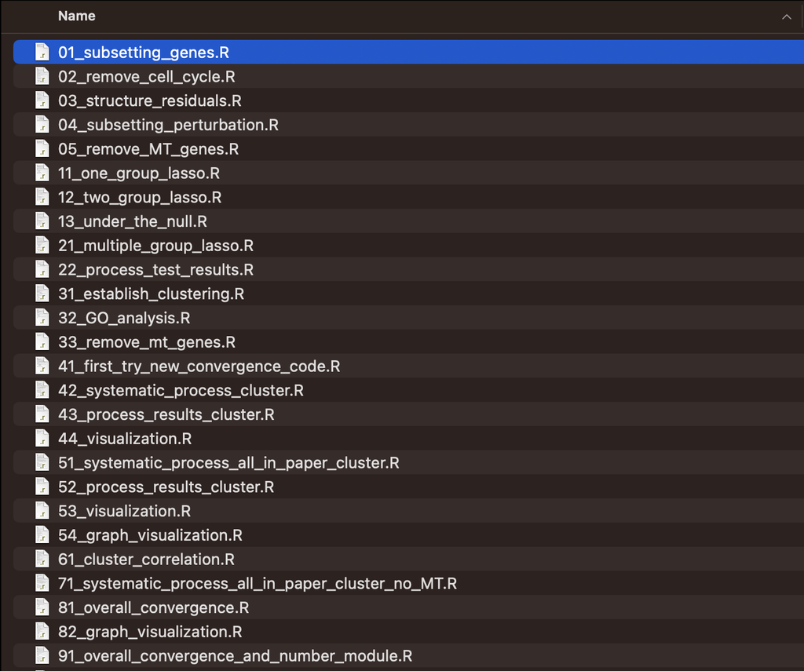

0-9, A, B,…

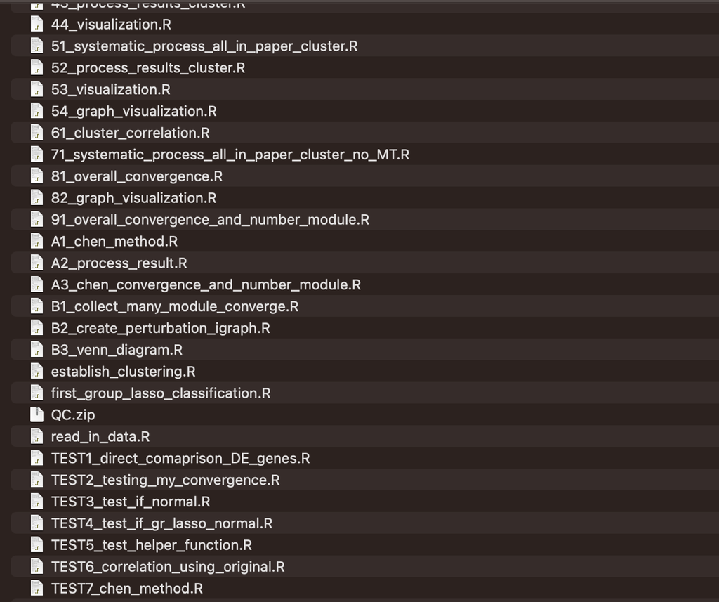

Test scripts are placed at the end of the file sequence.

As you will see, all the lecture notes will follow this naming pattern.

## Match output files to their generators

Keep output names consistent with the scripts that produce them. This makes your project more self-documenting.

- 01-clean-data.R -> data/01-clean-data.csv
- 02-model-fit.R -> data/02-linear-model.rds
- 03-visualization.R -> figs/03-residual-plot.png

In `01-load-data.R`, write

```r
write_csv(cleaned, file = "data/01-raw-clean.csv")
```

# Tabular data and their layouts

## Tabular data

Tabular data is the most common data storage format, but there are always multiple possible tabular layouts for the same underlying information.

## Reading data

Files in `.csv` format are easy to process. Almost a luxury in practice.

```r
library(tidyverse)
mammal_data <- read_csv("data/allison1976.csv")
mammal_data[, 1:6]
```

```
# A tibble: 62 × 6
   species                 body_wt brain_wt non_dreaming dreaming total_sleep
   <chr>                     <dbl>    <dbl>        <dbl>    <dbl>       <dbl>
 1 Africanelephant        6654       5712           NA       NA           3.3
 2 Africangiantpouchedrat    1          6.6          6.3      2           8.3
 3 ArcticFox                 3.38      44.5         NA       NA          12.5
 4 Arcticgroundsquirrel      0.92       5.7         NA       NA          16.5
 5 Asianelephant          2547       4603            2.1      1.8         3.9
 6 Baboon                   10.6      180.           9.1      0.7         9.8
 7 Bigbrownbat               0.023      0.3         15.8      3.9        19.7
 8 Braziliantapir          160        169            5.2      1           6.2
 9 Cat                       3.3       25.6         10.9      3.6        14.5
10 Chimpanzee               52.2      440            8.3      1.4         9.7
# ℹ 52 more rows
```

Function `read_csv` is part of the `readr` package (which is loaded when importing `tidyverse`). The `tibble` class are easier to examine than the default `data.frame`.

```r
mammal_data <- read.csv("data/allison1976.csv")
mammal_data[, 1:6]
```

```
                   species  body_wt brain_wt non_dreaming dreaming total_sleep
1          Africanelephant 6654.000  5712.00           NA       NA         3.3
2   Africangiantpouchedrat    1.000     6.60          6.3      2.0         8.3
3                ArcticFox    3.385    44.50           NA       NA        12.5
4     Arcticgroundsquirrel    0.920     5.70           NA       NA        16.5
5            Asianelephant 2547.000  4603.00          2.1      1.8         3.9
6                   Baboon   10.550   179.50          9.1      0.7         9.8
7              Bigbrownbat    0.023     0.30         15.8      3.9        19.7
8           Braziliantapir  160.000   169.00          5.2      1.0         6.2
9                      Cat    3.300    25.60         10.9      3.6        14.5
10              Chimpanzee   52.160   440.00          8.3      1.4         9.7
11              Chinchilla    0.425     6.40         11.0      1.5        12.5
12                     Cow  465.000   423.00          3.2      0.7         3.9
13          Deserthedgehog    0.550     2.40          7.6      2.7        10.3
14                  Donkey  187.100   419.00           NA       NA         3.1
```

[output cut: 48 more lines]

## Piping

- Pipes, `|>` or `%>%`, are used to chain a sequence of operations.
- Makes code more readable and concise
- The pipe operator takes the output of one function and passes it as the first argument to the next function.
- `%>%` in `tidyverse` syntax or `|>` from base R.
- There are subtle differences between them. I will try to stick to `|>`, which has slightly stricter syntax.

## Piping

```r
mammal_data[startsWith(mammal_data$species, "African"),
            c("species", "body_wt", "brain_wt")]
```

```
                 species body_wt brain_wt
1        Africanelephant    6654   5712.0
2 Africangiantpouchedrat       1      6.6
```

is the same as…

```r
filtered_data <- filter(.data=mammal_data,
                        startsWith(species, "African"))
select(filtered_data, species, body_wt, brain_wt)
```

```
                 species body_wt brain_wt
1        Africanelephant    6654   5712.0
2 Africangiantpouchedrat       1      6.6
```

is the same as…

```r
## Piping approach
mammal_data |>
  filter(startsWith(species, "African")) |>
  select(species, body_wt, brain_wt)
```

```
                 species body_wt brain_wt
1        Africanelephant    6654   5712.0
2 Africangiantpouchedrat       1      6.6
```

I used base R for many years and gradually shifted toward using piping because of its clarity.

## Long vs Wide Tables

- Different layouts but the same information
- Different functions/tools require different layouts
- Let’s explore the layouts and their tradeoffs

## Mammal data: long layouts

Below is the Allison 1976 mammal brain-body weight dataset shown in two ‘long’ layouts:

```r
# import brain and body weights
mammal1 <- read_csv('data/allison1976.csv') |> select(1:3)
mammal1
```

```
# A tibble: 62 × 3
   species                 body_wt brain_wt
   <chr>                     <dbl>    <dbl>
 1 Africanelephant        6654       5712
 2 Africangiantpouchedrat    1          6.6
 3 ArcticFox                 3.38      44.5
 4 Arcticgroundsquirrel      0.92       5.7
 5 Asianelephant          2547       4603
 6 Baboon                   10.6      180.
 7 Bigbrownbat               0.023      0.3
 8 Braziliantapir          160        169
 9 Cat                       3.3       25.6
10 Chimpanzee               52.2      440
# ℹ 52 more rows
```

## Longer layout

I can reorganize the numbers…

```
# A tibble: 124 × 3
   species                measurement  weight
   <chr>                  <chr>         <dbl>
 1 Africanelephant        body_wt     6654
 2 Africanelephant        brain_wt    5712
 3 Africangiantpouchedrat body_wt        1
 4 Africangiantpouchedrat brain_wt       6.6
 5 ArcticFox              body_wt        3.38
 6 ArcticFox              brain_wt      44.5
 7 Arcticgroundsquirrel   body_wt        0.92
 8 Arcticgroundsquirrel   brain_wt       5.7
 9 Asianelephant          body_wt     2547
10 Asianelephant          brain_wt    4603
# ℹ 114 more rows
```

Is it a good idea to put the numerical values of body weights and brain weights in the same column?

## Wide format

```
# A tibble: 2 × 63
  measurement Africanelephant Africangiantpouchedrat ArcticFox
  <chr>                 <dbl>                  <dbl>     <dbl>
1 body_wt                6654                    1        3.38
2 brain_wt               5712                    6.6     44.5
# ℹ 59 more variables: Arcticgroundsquirrel <dbl>, Asianelephant <dbl>,
#   Baboon <dbl>, Bigbrownbat <dbl>, Braziliantapir <dbl>, Cat <dbl>,
#   Chimpanzee <dbl>, Chinchilla <dbl>, Cow <dbl>, Deserthedgehog <dbl>,
#   Donkey <dbl>, EasternAmericanmole <dbl>, Echidna <dbl>,
#   Europeanhedgehog <dbl>, Galago <dbl>, Genet <dbl>, Giantarmadillo <dbl>,
#   Giraffe <dbl>, Goat <dbl>, Goldenhamster <dbl>, Gorilla <dbl>,
#   Grayseal <dbl>, Graywolf <dbl>, Groundsquirrel <dbl>, Guineapig <dbl>, …
```

```r
mammal3 |> rownames()
```

```
[1] "1" "2"
```

```r
mammal3 |> colnames()
```

```
 [1] "measurement"             "Africanelephant"
 [3] "Africangiantpouchedrat"  "ArcticFox"
 [5] "Arcticgroundsquirrel"    "Asianelephant"
 [7] "Baboon"                  "Bigbrownbat"
 [9] "Braziliantapir"          "Cat"
[11] "Chimpanzee"              "Chinchilla"
[13] "Cow"                     "Deserthedgehog"
[15] "Donkey"                  "EasternAmericanmole"
[17] "Echidna"                 "Europeanhedgehog"
[19] "Galago"                  "Genet"
[21] "Giantarmadillo"          "Giraffe"
[23] "Goat"                    "Goldenhamster"
[25] "Gorilla"                 "Grayseal"
[27] "Graywolf"                "Groundsquirrel"
[29] "Guineapig"               "Horse"
```

[output cut: 17 more lines]

## GDP growth data: wide layout

Here’s another example: World Bank data on annual GDP growth for 264 countries from 1961 – 2019. The raw layout is shown below.

```r
gdp1 <- read_csv('data/annual_growth.csv')
gdp1
```

```
# A tibble: 264 × 61
   `Country Name`       `Country Code` `1961` `1962` `1963` `1964` `1965` `1966`
   <chr>                <chr>           <dbl>  <dbl>  <dbl>  <dbl>  <dbl>  <dbl>
 1 Aruba                ABW             NA    NA      NA      NA     NA   NA
 2 Afghanistan          AFG             NA    NA      NA      NA     NA   NA
 3 Angola               AGO             NA    NA      NA      NA     NA   NA
 4 Albania              ALB             NA    NA      NA      NA     NA   NA
 5 Andorra              AND             NA    NA      NA      NA     NA   NA
 6 Arab World           ARB             NA    NA      NA      NA     NA   NA
 7 United Arab Emirates ARE             NA    NA      NA      NA     NA   NA
 8 Argentina            ARG              5.43 -0.852  -5.31   10.1   10.6 -0.660
 9 Armenia              ARM             NA    NA      NA      NA     NA   NA
10 American Samoa       ASM             NA    NA      NA      NA     NA   NA
# ℹ 254 more rows
# ℹ 53 more variables: `1967` <dbl>, `1968` <dbl>, `1969` <dbl>, `1970` <dbl>,
#   `1971` <dbl>, `1972` <dbl>, `1973` <dbl>, `1974` <dbl>, `1975` <dbl>,
#   `1976` <dbl>, `1977` <dbl>, `1978` <dbl>, `1979` <dbl>, `1980` <dbl>,
#   `1981` <dbl>, `1982` <dbl>, `1983` <dbl>, `1984` <dbl>, `1985` <dbl>,
#   `1986` <dbl>, `1987` <dbl>, `1988` <dbl>, `1989` <dbl>, `1990` <dbl>,
#   `1991` <dbl>, `1992` <dbl>, `1993` <dbl>, `1994` <dbl>, `1995` <dbl>, …
```

Let us reflect on how the row and column numbers relate to the information encoded in the data.

## GDP growth data: long layout

Here’s an alternative layout for the annual GDP growth data:

```
# A tibble: 15,576 × 4
   `Country Name`      `Country Code` year     GDP
   <chr>               <chr>          <chr>  <dbl>
 1 Afghanistan         AFG            1961   NA
 2 Albania             ALB            1961   NA
 3 Algeria             DZA            1961  -13.6
 4 American Samoa      ASM            1961   NA
 5 Andorra             AND            1961   NA
 6 Angola              AGO            1961   NA
 7 Antigua and Barbuda ATG            1961   NA
 8 Arab World          ARB            1961   NA
 9 Argentina           ARG            1961    5.43
10 Armenia             ARM            1961   NA
# ℹ 15,566 more rows
```

Now each row corresponds to a unique combination of country and year. Why this row number?

```r
nrow(gdp1) * (ncol(gdp1) - 2) #264 * 59
```

```
[1] 15576
```

## SB weather data: long layouts

A third example: daily minimum and maximum temperatures recorded at Santa Barbara Municipal Airport from January 2021 through March 2021.

```r
weather1 <- read_csv('data/sb_weather.csv')
weather1
```

```
# A tibble: 88 × 5
   STATION     NAME                                   DATE       TMAX  TMIN
   <chr>       <chr>                                  <chr>     <dbl> <dbl>
 1 USW00023190 SANTA BARBARA MUNICIPAL AIRPORT, CA US 1/1/2021     65    37
 2 USW00023190 SANTA BARBARA MUNICIPAL AIRPORT, CA US 1/2/2021     62    38
 3 USW00023190 SANTA BARBARA MUNICIPAL AIRPORT, CA US 1/3/2021     60    42
 4 USW00023190 SANTA BARBARA MUNICIPAL AIRPORT, CA US 1/4/2021     72    43
 5 USW00023190 SANTA BARBARA MUNICIPAL AIRPORT, CA US 1/5/2021     61    40
 6 USW00023190 SANTA BARBARA MUNICIPAL AIRPORT, CA US 1/6/2021     71    39
 7 USW00023190 SANTA BARBARA MUNICIPAL AIRPORT, CA US 1/7/2021     73    38
 8 USW00023190 SANTA BARBARA MUNICIPAL AIRPORT, CA US 1/8/2021     79    36
 9 USW00023190 SANTA BARBARA MUNICIPAL AIRPORT, CA US 1/9/2021     71    39
10 USW00023190 SANTA BARBARA MUNICIPAL AIRPORT, CA US 1/10/2021    67    37
# ℹ 78 more rows
```

Dates can be confusing. Some countries use MM/DD/YYYY, but some use YYYY/MM/DD or DD/MM/YYYY. Time zones and daylight saving changes.

## SB weather data: long layouts

```r
# convert to date format specifying month/day/year format
weather1 <- weather1 |> mutate(DATE = mdy(DATE))
## from the lubridate package, lubridate::mdy
weather1
```

```
# A tibble: 88 × 5
   STATION     NAME                                   DATE        TMAX  TMIN
   <chr>       <chr>                                  <date>     <dbl> <dbl>
 1 USW00023190 SANTA BARBARA MUNICIPAL AIRPORT, CA US 2021-01-01    65    37
 2 USW00023190 SANTA BARBARA MUNICIPAL AIRPORT, CA US 2021-01-02    62    38
 3 USW00023190 SANTA BARBARA MUNICIPAL AIRPORT, CA US 2021-01-03    60    42
 4 USW00023190 SANTA BARBARA MUNICIPAL AIRPORT, CA US 2021-01-04    72    43
 5 USW00023190 SANTA BARBARA MUNICIPAL AIRPORT, CA US 2021-01-05    61    40
 6 USW00023190 SANTA BARBARA MUNICIPAL AIRPORT, CA US 2021-01-06    71    39
 7 USW00023190 SANTA BARBARA MUNICIPAL AIRPORT, CA US 2021-01-07    73    38
 8 USW00023190 SANTA BARBARA MUNICIPAL AIRPORT, CA US 2021-01-08    79    36
 9 USW00023190 SANTA BARBARA MUNICIPAL AIRPORT, CA US 2021-01-09    71    39
10 USW00023190 SANTA BARBARA MUNICIPAL AIRPORT, CA US 2021-01-10    67    37
# ℹ 78 more rows
```

We can also separate the day, month and year.

```
# A tibble: 88 × 5
     DAY MONTH  YEAR  TMAX  TMIN
   <int> <dbl> <dbl> <dbl> <dbl>
 1     1     1  2021    65    37
 2     2     1  2021    62    38
 3     3     1  2021    60    42
 4     4     1  2021    72    43
 5     5     1  2021    61    40
 6     6     1  2021    71    39
 7     7     1  2021    73    38
 8     8     1  2021    79    36
 9     9     1  2021    71    39
10    10     1  2021    67    37
# ℹ 78 more rows
```

What is the maximum temperature of 1/7/2021?

## SB weather data: wide layouts

Not all datasets are stored in the most comprehensible format when we obtain them.

```
# A tibble: 6 × 36
  STATION     NAME   MONTH  YEAR Type    `1`   `2`   `3`   `4`   `5`   `6`   `7`
  <chr>       <chr>  <dbl> <dbl> <chr> <dbl> <dbl> <dbl> <dbl> <dbl> <dbl> <dbl>
1 USW00023190 SANTA…     1  2021 TMAX     65    62    60    72    61    71    73
2 USW00023190 SANTA…     1  2021 TMIN     37    38    42    43    40    39    38
3 USW00023190 SANTA…     2  2021 TMAX     66    67    69    63    66    68    60
4 USW00023190 SANTA…     2  2021 TMIN     45    40    44    37    38    38    38
5 USW00023190 SANTA…     3  2021 TMAX     68    66    59    62    67    69    60
6 USW00023190 SANTA…     3  2021 TMIN     37    36    36    37    39    43    47
# ℹ 24 more variables: `8` <dbl>, `9` <dbl>, `10` <dbl>, `11` <dbl>,
#   `12` <dbl>, `13` <dbl>, `14` <dbl>, `15` <dbl>, `16` <dbl>, `17` <dbl>,
#   `18` <dbl>, `19` <dbl>, `20` <dbl>, `21` <dbl>, `22` <dbl>, `23` <dbl>,
#   `24` <dbl>, `25` <dbl>, `26` <dbl>, `27` <dbl>, `28` <dbl>, `29` <dbl>,
#   `30` <dbl>, `31` <dbl>
```

What is the maximum temperature of 1/7/2021? Easier or harder to process the information than the previous layout?

## UN development data: multiple tables

A final example: United Nations country (and regions) development data organized into different tables according to variable type.

```r
undev1 <- read_csv('data/hdi3.csv', na = '..') |> select(-hdi_rank)
#not keeping column hdi_rank

undev2 <- read_csv('data/hdi2.csv', na = '..') |>
    select(-one_of(c('hdi_rank', 'maternal_mortality')))
```

Here is a table of population measurements:

```r
undev1
```

```
# A tibble: 189 × 6
   country              total_pop urban_pct_pop pop_under5 pop_15to64 pop_over65
   <chr>                    <dbl>         <dbl>      <dbl>      <dbl>      <dbl>
 1 Norway                     5.4          82.6        0.3        3.5        0.9
 2 Ireland                    4.9          63.4        0.3        3.2        0.7
 3 Switzerland                8.6          73.8        0.4        5.7        1.6
 4 Hong Kong, China (S…       7.4         100          0.3        5.2        1.3
 5 Iceland                    0.3          93.9        0          0.2        0.1
 6 Germany                   83.5          77.4        4         54         18
 7 Sweden                    10            87.7        0.6        6.2        2
 8 Australia                 25.2          86.1        1.7       16.3        4
 9 Netherlands               17.1          91.9        0.9       11          3.4
10 Denmark                    5.8          88          0.3        3.7        1.2
# ℹ 179 more rows
```

And here is a table of a few gender-related variables:

```r
undev2
```

```
# A tibble: 189 × 5
   country         gender_inequality parliament_pct_women labor_participation_…¹
   <chr>                       <dbl>                <dbl>                  <dbl>
 1 Norway                      0.045                 40.8                   60.4
 2 Ireland                     0.093                 24.3                   56
 3 Switzerland                 0.025                 38.6                   62.9
 4 Hong Kong, Chi…            NA                     NA                     54
 5 Iceland                     0.058                 38.1                   70.8
 6 Germany                     0.084                 31.6                   55.3
 7 Sweden                      0.039                 47.3                   61.4
 8 Australia                   0.097                 36.6                   60.3
 9 Netherlands                 0.043                 33.8                   58.3
10 Denmark                     0.038                 39.1                   58.2
# ℹ 179 more rows
# ℹ abbreviated name: ¹labor_participation_women
# ℹ 1 more variable: labor_participation_men <dbl>
```

## UN development data: one table

```r
identical(undev1$country, undev2$country)
```

```
[1] TRUE
```

We combine / merge the two tables by country:

```
# A tibble: 189 × 10
   country              total_pop urban_pct_pop pop_under5 pop_15to64 pop_over65
   <chr>                    <dbl>         <dbl>      <dbl>      <dbl>      <dbl>
 1 Norway                     5.4          82.6        0.3        3.5        0.9
 2 Ireland                    4.9          63.4        0.3        3.2        0.7
 3 Switzerland                8.6          73.8        0.4        5.7        1.6
 4 Hong Kong, China (S…       7.4         100          0.3        5.2        1.3
 5 Iceland                    0.3          93.9        0          0.2        0.1
 6 Germany                   83.5          77.4        4         54         18
 7 Sweden                    10            87.7        0.6        6.2        2
 8 Australia                 25.2          86.1        1.7       16.3        4
 9 Netherlands               17.1          91.9        0.9       11          3.4
10 Denmark                    5.8          88          0.3        3.7        1.2
# ℹ 179 more rows
# ℹ 4 more variables: gender_inequality <dbl>, parliament_pct_women <dbl>,
#   labor_participation_women <dbl>, labor_participation_men <dbl>
```

```r
glimpse(undev_combined1)
```

```
Rows: 189
Columns: 10
$ country                   <chr> "Norway", "Ireland", "Switzerland", "Hong Ko…
$ total_pop                 <dbl> 5.4, 4.9, 8.6, 7.4, 0.3, 83.5, 10.0, 25.2, 1…
$ urban_pct_pop             <dbl> 82.6, 63.4, 73.8, 100.0, 93.9, 77.4, 87.7, 8…
$ pop_under5                <dbl> 0.3, 0.3, 0.4, 0.3, 0.0, 4.0, 0.6, 1.7, 0.9,…
$ pop_15to64                <dbl> 3.5, 3.2, 5.7, 5.2, 0.2, 54.0, 6.2, 16.3, 11…
$ pop_over65                <dbl> 0.9, 0.7, 1.6, 1.3, 0.1, 18.0, 2.0, 4.0, 3.4…
$ gender_inequality         <dbl> 0.045, 0.093, 0.025, NA, 0.058, 0.084, 0.039…
$ parliament_pct_women      <dbl> 40.8, 24.3, 38.6, NA, 38.1, 31.6, 47.3, 36.6…
$ labor_participation_women <dbl> 60.4, 56.0, 62.9, 54.0, 70.8, 55.3, 61.4, 60…
$ labor_participation_men   <dbl> 67.2, 68.4, 73.8, 67.5, 79.2, 66.6, 67.8, 70…
```

## UN development data: one (longer) table

And here is another arrangement of the merged table:

```
# A tibble: 3,780 × 5
   country gender_variable     gender_value population_variable population_value
   <chr>   <chr>                      <dbl> <chr>                          <dbl>
 1 Norway  gender_inequality          0.045 total_pop                        5.4
 2 Norway  gender_inequality          0.045 urban_pct_pop                   82.6
 3 Norway  gender_inequality          0.045 pop_under5                       0.3
 4 Norway  gender_inequality          0.045 pop_15to64                       3.5
 5 Norway  gender_inequality          0.045 pop_over65                       0.9
 6 Norway  parliament_pct_wom…       40.8   total_pop                        5.4
 7 Norway  parliament_pct_wom…       40.8   urban_pct_pop                   82.6
 8 Norway  parliament_pct_wom…       40.8   pop_under5                       0.3
 9 Norway  parliament_pct_wom…       40.8   pop_15to64                       3.5
10 Norway  parliament_pct_wom…       40.8   pop_over65                       0.9
# ℹ 3,770 more rows
```

Same information but…

## Few organizational constraints

It’s surprisingly difficult to articulate reasons why one layout might be preferable to another.

Most data are stored in a layout that made intuitive sense to someone responsible for data management or collection at some point in time.

- Usually the choice of layout isn’t principled
- Two people are likely to make different choices

## Consequences for the data scientist

Data scientists are constantly faced with determining how best to reorganize datasets in a way that **facilitates exploration and analysis**.

Broadly, this involves two interdependent choices:

- *Choice of **representation**: how to encode information.*
  - Parse dates as ‘YYYY-MM-DD’ (one variable) or ‘MM’, ‘DD’, ‘YYYY’ (three variables)?
  - Use values 1, 2, 3 or ‘low’, ‘med’, ‘high’ for ordinal variables?
- *Choice of **layout**: how to display information*
  - Wide table or long table?
  - One table or several tables?

# Tidy data as a standard for better layouts

## The Tidy data standard

- **Tidy data** is one of the most important systematic efforts to answer a basic question: *what counts as a good tabular layout?*

**Credit** - Articulated and popularized by **Hadley Wickham** (Journal of Statistical Software, 2014); his broader contributions were recognized with the 2019 COPSS Presidents’ Award.

## The tidy standard

A tabular data set is a collection of **values**. A data set conforming to the **tidy standard** is organized so that:

1. Each row corresponds to one observation unit (a person).
2. Each column corresponds to one variable (weight, height, …).
3. Each type of observational unit forms a table (will be explained later).

> “Happy families are all alike; every unhappy family is unhappy in its own way” *Leo Tolstoy*

## Tidy or messy?

Let’s learn about the tidy data standard through examples.

Suppose we want to create a table containing the body and brain weights for several species of mammals.

It feels natural to treat one species as the observational unit.

```r
mammal2
```

```
# A tibble: 124 × 3
   species                measurement  weight
   <chr>                  <chr>         <dbl>
 1 Africanelephant        body_wt     6654
 2 Africanelephant        brain_wt    5712
 3 Africangiantpouchedrat body_wt        1
 4 Africangiantpouchedrat brain_wt       6.6
 5 ArcticFox              body_wt        3.38
 6 ArcticFox              brain_wt      44.5
 7 Arcticgroundsquirrel   body_wt        0.92
 8 Arcticgroundsquirrel   brain_wt       5.7
 9 Asianelephant          body_wt     2547
10 Asianelephant          brain_wt    4603
# ℹ 114 more rows
```

Is this layout tidy?

No. A single observational unit is spread across multiple rows, which violates the tidy data principle that each observational unit should correspond to exactly one row.

## Tidy or messy?

Suppose we are maintaining a table of annual GDP growth for several countries.

```r
head(gdp1, n=3)
```

```
# A tibble: 3 × 61
  `Country Name` `Country Code` `1961` `1962` `1963` `1964` `1965` `1966` `1967`
  <chr>          <chr>           <dbl>  <dbl>  <dbl>  <dbl>  <dbl>  <dbl>  <dbl>
1 Aruba          ABW                NA     NA     NA     NA     NA     NA     NA
2 Afghanistan    AFG                NA     NA     NA     NA     NA     NA     NA
3 Angola         AGO                NA     NA     NA     NA     NA     NA     NA
# ℹ 52 more variables: `1968` <dbl>, `1969` <dbl>, `1970` <dbl>, `1971` <dbl>,
#   `1972` <dbl>, `1973` <dbl>, `1974` <dbl>, `1975` <dbl>, `1976` <dbl>,
#   `1977` <dbl>, `1978` <dbl>, `1979` <dbl>, `1980` <dbl>, `1981` <dbl>,
#   `1982` <dbl>, `1983` <dbl>, `1984` <dbl>, `1985` <dbl>, `1986` <dbl>,
#   `1987` <dbl>, `1988` <dbl>, `1989` <dbl>, `1990` <dbl>, `1991` <dbl>,
#   `1992` <dbl>, `1993` <dbl>, `1994` <dbl>, `1995` <dbl>, `1996` <dbl>,
#   `1997` <dbl>, `1998` <dbl>, `1999` <dbl>, `2000` <dbl>, `2001` <dbl>, …
```

A unique combination of country and year (USA, 1980) may be the natural observational unit.

Is this table tidy?

Each row corresponds to many years of the same country, not tidy.

However, for some analysis, one country may be viewed as the natural observational unit. If that is the case then the current table is OK (but I don’t like it contains so many NAs that could have been avoided).

## Tidy or messy?

We want to tidy a table of Santa Barbara’s daily temperatures, including both the daily high and daily low. What would be a natural observational unit?

One day?

```r
head(weather2, n=4)
```

```
# A tibble: 4 × 8
  STATION     NAME                      DATE        TMAX  TMIN   DAY MONTH  YEAR
  <chr>       <chr>                     <date>     <dbl> <dbl> <int> <dbl> <dbl>
1 USW00023190 SANTA BARBARA MUNICIPAL … 2021-01-01    65    37     1     1  2021
2 USW00023190 SANTA BARBARA MUNICIPAL … 2021-01-02    62    38     2     1  2021
3 USW00023190 SANTA BARBARA MUNICIPAL … 2021-01-03    60    42     3     1  2021
4 USW00023190 SANTA BARBARA MUNICIPAL … 2021-01-04    72    43     4     1  2021
```

Is this table tidy?

## Rule 3: One observational unit, one table

Billboard dataset. Records song rankings on the Billboard music chart in the year 2000. Here is one possible layout.

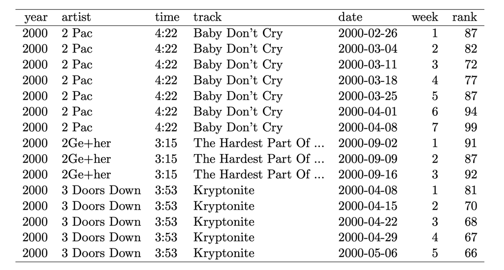

Each row records the rank of a song on a specific date.

`artist`, `time` and `track` are repeated for every song. Columns 2-4, the observational unit is one song; Columns 5-7, the unit is the combination of song and date.

Tidy standard states it is better to split into two tables

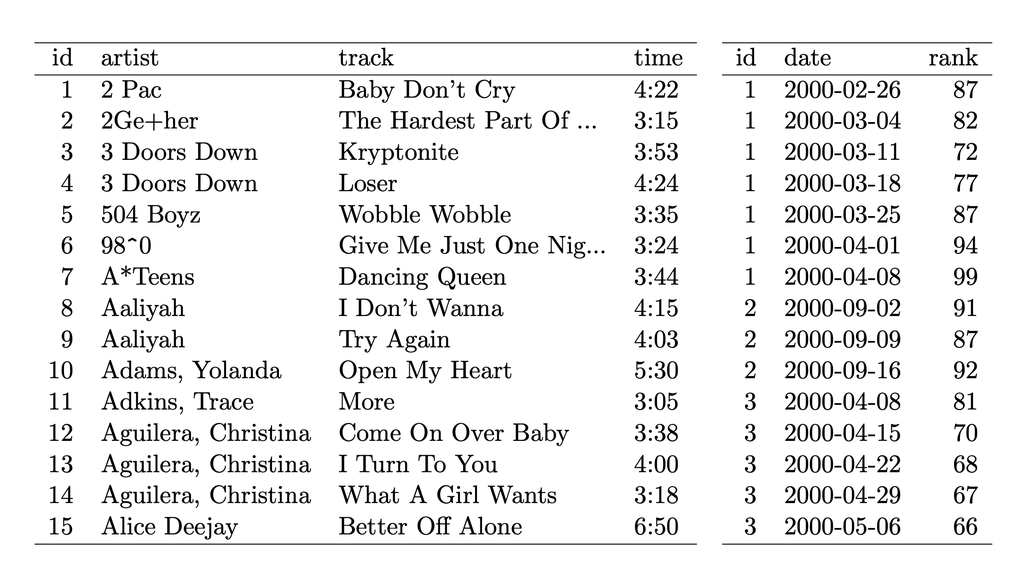

## Tidy or messy?

In `undev1` and `undev2`:

```r
undev1
```

```
# A tibble: 189 × 6
   country              total_pop urban_pct_pop pop_under5 pop_15to64 pop_over65
   <chr>                    <dbl>         <dbl>      <dbl>      <dbl>      <dbl>
 1 Norway                     5.4          82.6        0.3        3.5        0.9
 2 Ireland                    4.9          63.4        0.3        3.2        0.7
 3 Switzerland                8.6          73.8        0.4        5.7        1.6
 4 Hong Kong, China (S…       7.4         100          0.3        5.2        1.3
 5 Iceland                    0.3          93.9        0          0.2        0.1
 6 Germany                   83.5          77.4        4         54         18
 7 Sweden                    10            87.7        0.6        6.2        2
 8 Australia                 25.2          86.1        1.7       16.3        4
 9 Netherlands               17.1          91.9        0.9       11          3.4
10 Denmark                    5.8          88          0.3        3.7        1.2
# ℹ 179 more rows
```

```r
undev2
```

```
# A tibble: 189 × 5
   country         gender_inequality parliament_pct_women labor_participation_…¹
   <chr>                       <dbl>                <dbl>                  <dbl>
 1 Norway                      0.045                 40.8                   60.4
 2 Ireland                     0.093                 24.3                   56
 3 Switzerland                 0.025                 38.6                   62.9
 4 Hong Kong, Chi…            NA                     NA                     54
 5 Iceland                     0.058                 38.1                   70.8
 6 Germany                     0.084                 31.6                   55.3
 7 Sweden                      0.039                 47.3                   61.4
 8 Australia                   0.097                 36.6                   60.3
 9 Netherlands                 0.043                 33.8                   58.3
10 Denmark                     0.038                 39.1                   58.2
# ℹ 179 more rows
# ℹ abbreviated name: ¹labor_participation_women
# ℹ 1 more variable: labor_participation_men <dbl>
```

Here there are multiple tables.

- Are the observational units the same or different?
- Based on your answer above, is the data tidy or not?

# Long-wide conversion and table merging

**Long-wide conversion and table merging**

Common messes can be cleaned up by some simple operations:

- `pivot_longer`
  - reshape a table from wide to long format
- `pivot_wider`
  - reshape a table from long to wide format
- *joins*
  - combine two tables row-wise by matching the values of certain columns

## `pivot_longer`

Pivoting longer resolves the problem of storing multiple observations in one row.

**Column names** become **values** in the table.

## `pivot_longer`

To illustrate with `gdp1`:

```r
head(gdp1, n=3)
```

```
# A tibble: 3 × 61
  `Country Name` `Country Code` `1961` `1962` `1963` `1964` `1965` `1966` `1967`
  <chr>          <chr>           <dbl>  <dbl>  <dbl>  <dbl>  <dbl>  <dbl>  <dbl>
1 Aruba          ABW                NA     NA     NA     NA     NA     NA     NA
2 Afghanistan    AFG                NA     NA     NA     NA     NA     NA     NA
3 Angola         AGO                NA     NA     NA     NA     NA     NA     NA
# ℹ 52 more variables: `1968` <dbl>, `1969` <dbl>, `1970` <dbl>, `1971` <dbl>,
#   `1972` <dbl>, `1973` <dbl>, `1974` <dbl>, `1975` <dbl>, `1976` <dbl>,
#   `1977` <dbl>, `1978` <dbl>, `1979` <dbl>, `1980` <dbl>, `1981` <dbl>,
#   `1982` <dbl>, `1983` <dbl>, `1984` <dbl>, `1985` <dbl>, `1986` <dbl>,
#   `1987` <dbl>, `1988` <dbl>, `1989` <dbl>, `1990` <dbl>, `1991` <dbl>,
#   `1992` <dbl>, `1993` <dbl>, `1994` <dbl>, `1995` <dbl>, `1996` <dbl>,
#   `1997` <dbl>, `1998` <dbl>, `1999` <dbl>, `2000` <dbl>, `2001` <dbl>, …
```

Please read the comments for the three arguments:

```r
gdp1 |> pivot_longer(cols = 3:61, # which columns do I want to change into values?
                     names_to = "Year",   # store former column names as values under "Year"
                     values_to = "GDP") |>    # store the values of original columns under "GDP"
  arrange(`Country Name`, Year)  # sort the dataset by Country Name first, then by Year
```

```
# A tibble: 15,576 × 4
   `Country Name` `Country Code` Year    GDP
   <chr>          <chr>          <chr> <dbl>
 1 Afghanistan    AFG            1961     NA
 2 Afghanistan    AFG            1962     NA
 3 Afghanistan    AFG            1963     NA
 4 Afghanistan    AFG            1964     NA
 5 Afghanistan    AFG            1965     NA
 6 Afghanistan    AFG            1966     NA
 7 Afghanistan    AFG            1967     NA
 8 Afghanistan    AFG            1968     NA
 9 Afghanistan    AFG            1969     NA
10 Afghanistan    AFG            1970     NA
# ℹ 15,566 more rows
```

## Pivoting to a wider format

Pivoting to a wider format resolves the issue of having one unit stored in multiple rows.

**Values** are converted into **column names**.

## Pivot wider

For example, the `mammal2` layout can be put in tidier form with `pivot_wider`:

```r
head(mammal2, n=3)
```

```
# A tibble: 3 × 3
  species                measurement weight
  <chr>                  <chr>        <dbl>
1 Africanelephant        body_wt       6654
2 Africanelephant        brain_wt      5712
3 Africangiantpouchedrat body_wt          1
```

```r
mammal2 |> pivot_wider(
    names_from = 'measurement', # which variable(s) do you want to use as new column names?
    values_from = 'weight' # which variable(s) do you want to use to populate the new columns?
)
```

```
# A tibble: 62 × 3
   species                 body_wt brain_wt
   <chr>                     <dbl>    <dbl>
 1 Africanelephant        6654       5712
 2 Africangiantpouchedrat    1          6.6
 3 ArcticFox                 3.38      44.5
 4 Arcticgroundsquirrel      0.92       5.7
 5 Asianelephant          2547       4603
 6 Baboon                   10.6      180.
 7 Bigbrownbat               0.023      0.3
 8 Braziliantapir          160        169
 9 Cat                       3.3       25.6
10 Chimpanzee               52.2      440
# ℹ 52 more rows
```

## Pivot longer and wider

Sometimes we have a combination of multiple messes. Table `weather3` illustrates this issue.

Let’s assume we agree that one day is the natural observational unit.

```r
weather3
```

```
# A tibble: 6 × 36
  STATION     NAME   MONTH  YEAR Type    `1`   `2`   `3`   `4`   `5`   `6`   `7`
  <chr>       <chr>  <dbl> <dbl> <chr> <dbl> <dbl> <dbl> <dbl> <dbl> <dbl> <dbl>
1 USW00023190 SANTA…     1  2021 TMAX     65    62    60    72    61    71    73
2 USW00023190 SANTA…     1  2021 TMIN     37    38    42    43    40    39    38
3 USW00023190 SANTA…     2  2021 TMAX     66    67    69    63    66    68    60
4 USW00023190 SANTA…     2  2021 TMIN     45    40    44    37    38    38    38
5 USW00023190 SANTA…     3  2021 TMAX     68    66    59    62    67    69    60
6 USW00023190 SANTA…     3  2021 TMIN     37    36    36    37    39    43    47
# ℹ 24 more variables: `8` <dbl>, `9` <dbl>, `10` <dbl>, `11` <dbl>,
#   `12` <dbl>, `13` <dbl>, `14` <dbl>, `15` <dbl>, `16` <dbl>, `17` <dbl>,
#   `18` <dbl>, `19` <dbl>, `20` <dbl>, `21` <dbl>, `22` <dbl>, `23` <dbl>,
#   `24` <dbl>, `25` <dbl>, `26` <dbl>, `27` <dbl>, `28` <dbl>, `29` <dbl>,
#   `30` <dbl>, `31` <dbl>
```

## Pivot longer and wider

First `pivot_longer`…

```r
## First move date columns into a variable
weather3_long <- weather3 |>
  pivot_longer(cols = 6:36, # original columns
    names_to = 'day', # new column storing column names
    values_to = 'temp')  |> # new column storing values
  arrange(day)
weather3_long
```

```
# A tibble: 186 × 7
   STATION     NAME                                MONTH  YEAR Type  day    temp
   <chr>       <chr>                               <dbl> <dbl> <chr> <chr> <dbl>
 1 USW00023190 SANTA BARBARA MUNICIPAL AIRPORT, C…     1  2021 TMAX  1        65
 2 USW00023190 SANTA BARBARA MUNICIPAL AIRPORT, C…     1  2021 TMIN  1        37
 3 USW00023190 SANTA BARBARA MUNICIPAL AIRPORT, C…     2  2021 TMAX  1        66
 4 USW00023190 SANTA BARBARA MUNICIPAL AIRPORT, C…     2  2021 TMIN  1        45
 5 USW00023190 SANTA BARBARA MUNICIPAL AIRPORT, C…     3  2021 TMAX  1        68
 6 USW00023190 SANTA BARBARA MUNICIPAL AIRPORT, C…     3  2021 TMIN  1        37
 7 USW00023190 SANTA BARBARA MUNICIPAL AIRPORT, C…     1  2021 TMAX  10       67
 8 USW00023190 SANTA BARBARA MUNICIPAL AIRPORT, C…     1  2021 TMIN  10       37
 9 USW00023190 SANTA BARBARA MUNICIPAL AIRPORT, C…     2  2021 TMAX  10       61
10 USW00023190 SANTA BARBARA MUNICIPAL AIRPORT, C…     2  2021 TMIN  10       41
# ℹ 176 more rows
```

## Pivot longer and wider

Then `pivot_wider`…

```r
weather3_tidy <- weather3_long |>
  pivot_wider(names_from = "Type", # variable providing new column names
              values_from = "temp") # variable providing values for new columns
weather3_tidy
```

```
# A tibble: 93 × 7
   STATION     NAME                                MONTH  YEAR day    TMAX  TMIN
   <chr>       <chr>                               <dbl> <dbl> <chr> <dbl> <dbl>
 1 USW00023190 SANTA BARBARA MUNICIPAL AIRPORT, C…     1  2021 1        65    37
 2 USW00023190 SANTA BARBARA MUNICIPAL AIRPORT, C…     2  2021 1        66    45
 3 USW00023190 SANTA BARBARA MUNICIPAL AIRPORT, C…     3  2021 1        68    37
 4 USW00023190 SANTA BARBARA MUNICIPAL AIRPORT, C…     1  2021 10       67    37
 5 USW00023190 SANTA BARBARA MUNICIPAL AIRPORT, C…     2  2021 10       61    41
 6 USW00023190 SANTA BARBARA MUNICIPAL AIRPORT, C…     3  2021 10       58    43
 7 USW00023190 SANTA BARBARA MUNICIPAL AIRPORT, C…     1  2021 11       67    36
 8 USW00023190 SANTA BARBARA MUNICIPAL AIRPORT, C…     2  2021 11       59    42
 9 USW00023190 SANTA BARBARA MUNICIPAL AIRPORT, C…     3  2021 11       56    38
10 USW00023190 SANTA BARBARA MUNICIPAL AIRPORT, C…     1  2021 12       68    37
# ℹ 83 more rows
```

## Pivot longer and wider

**All in one chunk**

```r
## First move date columns into a variable
weather3 |>
  pivot_longer(cols = 6:36,
               names_to = 'day',
               values_to = 'temp'
               ) |>
  pivot_wider(names_from = Type,
              values_from = temp)
```

```
# A tibble: 93 × 7
   STATION     NAME                                MONTH  YEAR day    TMAX  TMIN
   <chr>       <chr>                               <dbl> <dbl> <chr> <dbl> <dbl>
 1 USW00023190 SANTA BARBARA MUNICIPAL AIRPORT, C…     1  2021 1        65    37
 2 USW00023190 SANTA BARBARA MUNICIPAL AIRPORT, C…     1  2021 2        62    38
 3 USW00023190 SANTA BARBARA MUNICIPAL AIRPORT, C…     1  2021 3        60    42
 4 USW00023190 SANTA BARBARA MUNICIPAL AIRPORT, C…     1  2021 4        72    43
 5 USW00023190 SANTA BARBARA MUNICIPAL AIRPORT, C…     1  2021 5        61    40
 6 USW00023190 SANTA BARBARA MUNICIPAL AIRPORT, C…     1  2021 6        71    39
 7 USW00023190 SANTA BARBARA MUNICIPAL AIRPORT, C…     1  2021 7        73    38
 8 USW00023190 SANTA BARBARA MUNICIPAL AIRPORT, C…     1  2021 8        79    36
 9 USW00023190 SANTA BARBARA MUNICIPAL AIRPORT, C…     1  2021 9        71    39
10 USW00023190 SANTA BARBARA MUNICIPAL AIRPORT, C…     1  2021 10       67    37
# ℹ 83 more rows
```

## Inverted operations

`pivot_longer` transfers **column names** into **values**, then create another column to store original values.

`pivot_wider` transfers **values** into **column names**, distributing the values from another to-be-eliminated column to the new ones

## Pivoting

## Joins

Joining resolves the issue of storing observations or variables on one unit type in multiple tables. The basic idea is to combine by matching rows.

## Joins

We saw two tables storing the UN development information during the last lecture.

```r
undev1
```

```
# A tibble: 189 × 6
   country              total_pop urban_pct_pop pop_under5 pop_15to64 pop_over65
   <chr>                    <dbl>         <dbl>      <dbl>      <dbl>      <dbl>
 1 Norway                     5.4          82.6        0.3        3.5        0.9
 2 Ireland                    4.9          63.4        0.3        3.2        0.7
 3 Switzerland                8.6          73.8        0.4        5.7        1.6
 4 Hong Kong, China (S…       7.4         100          0.3        5.2        1.3
 5 Iceland                    0.3          93.9        0          0.2        0.1
 6 Germany                   83.5          77.4        4         54         18
 7 Sweden                    10            87.7        0.6        6.2        2
 8 Australia                 25.2          86.1        1.7       16.3        4
 9 Netherlands               17.1          91.9        0.9       11          3.4
10 Denmark                    5.8          88          0.3        3.7        1.2
# ℹ 179 more rows
```

```r
undev2
```

```
# A tibble: 189 × 5
   country         gender_inequality parliament_pct_women labor_participation_…¹
   <chr>                       <dbl>                <dbl>                  <dbl>
 1 Norway                      0.045                 40.8                   60.4
 2 Ireland                     0.093                 24.3                   56
 3 Switzerland                 0.025                 38.6                   62.9
 4 Hong Kong, Chi…            NA                     NA                     54
 5 Iceland                     0.058                 38.1                   70.8
 6 Germany                     0.084                 31.6                   55.3
 7 Sweden                      0.039                 47.3                   61.4
 8 Australia                   0.097                 36.6                   60.3
 9 Netherlands                 0.043                 33.8                   58.3
10 Denmark                     0.038                 39.1                   58.2
# ℹ 179 more rows
# ℹ abbreviated name: ¹labor_participation_women
# ℹ 1 more variable: labor_participation_men <dbl>
```

## Joins

The code below combines columns in each table by matching rows based on country.

```r
undev_joint <- inner_join(undev1, undev2, by = 'country')
glimpse(undev_joint)
```

```
Rows: 189
Columns: 10
$ country                   <chr> "Norway", "Ireland", "Switzerland", "Hong Ko…
$ total_pop                 <dbl> 5.4, 4.9, 8.6, 7.4, 0.3, 83.5, 10.0, 25.2, 1…
$ urban_pct_pop             <dbl> 82.6, 63.4, 73.8, 100.0, 93.9, 77.4, 87.7, 8…
$ pop_under5                <dbl> 0.3, 0.3, 0.4, 0.3, 0.0, 4.0, 0.6, 1.7, 0.9,…
$ pop_15to64                <dbl> 3.5, 3.2, 5.7, 5.2, 0.2, 54.0, 6.2, 16.3, 11…
$ pop_over65                <dbl> 0.9, 0.7, 1.6, 1.3, 0.1, 18.0, 2.0, 4.0, 3.4…
$ gender_inequality         <dbl> 0.045, 0.093, 0.025, NA, 0.058, 0.084, 0.039…
$ parliament_pct_women      <dbl> 40.8, 24.3, 38.6, NA, 38.1, 31.6, 47.3, 36.6…
$ labor_participation_women <dbl> 60.4, 56.0, 62.9, 54.0, 70.8, 55.3, 61.4, 60…
$ labor_participation_men   <dbl> 67.2, 68.4, 73.8, 67.5, 79.2, 66.6, 67.8, 70…
```

The two tables contain the same set of countries (and are even sorted in the same order!). Few decisions to make when merging them. Here we used `inner_join` for convenience.

## Why we need different types of joins

Suppose we have two tables: one recording GDP and another recording population. In both tables, the observational unit is country.

We want to join them to facilitate further analysis.

```r
GDP_table <- tibble(
  country = c("USA", "Canada", "Mexico"),
  gdp_trillion = c(25.5, 2.2, 1.3)
)

pop_table <- tibble(
  country = c("Canada", "Mexico", "Brazil"),
  population_million = c(39, 126, 214)
)
```

- What would be the final table if I only want to keep countries that have both GDP and population information.
- Keep all countries from the GDP table and add population information when available.
- Keep all countries, whether they have GDP, population, or both.

## Different rules

There are various rules for exactly how to join, but the general procedure to merge dataframes is:

- Specify **keys**: the shared columns to use for matching rows of `GDP_table` with rows of `pop_table`.
  - for example, `country` was the **key**.
- Specify a **rule** for how to handle unmatched rows. (e.g., `USA` in `GDP_table` but not in `pop_table`)

## Rule 1: inner join

Inner join: Keeps only keys that appear in both. (Keep only the `country`s appear in both `GDP_table` and `pop_table`.)

```r
inner_join(GDP_table, pop_table, by = "country")
```

```
# A tibble: 2 × 3
  country gdp_trillion population_million
  <chr>          <dbl>              <dbl>
1 Canada           2.2                 39
2 Mexico           1.3                126
```

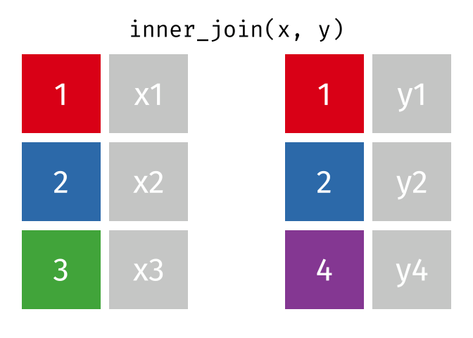

## Rule 2: left join

Left join: Keeps all keys from the left table (`GDP_table`), adds matches from `pop_table` when available. If not matched, usually filled with `NA`.

```r
left_join(GDP_table, pop_table, by = "country")
```

```
# A tibble: 3 × 3
  country gdp_trillion population_million
  <chr>          <dbl>              <dbl>
1 USA             25.5                 NA
2 Canada           2.2                 39
3 Mexico           1.3                126
```

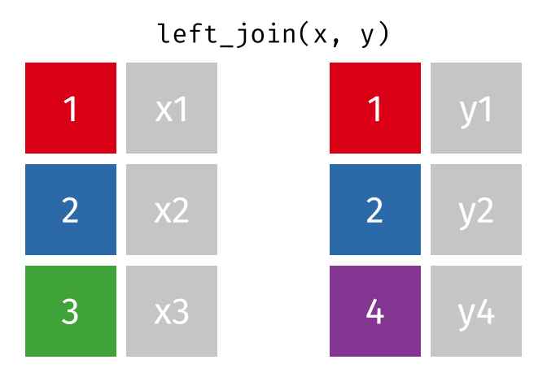

There is also a right join rule…

```r
right_join(GDP_table, pop_table, by = "country")
```

```
# A tibble: 3 × 3
  country gdp_trillion population_million
  <chr>          <dbl>              <dbl>
1 Canada           2.2                 39
2 Mexico           1.3                126
3 Brazil          NA                  214
```

```r
right_join(pop_table, GDP_table, by = "country")
```

```
# A tibble: 3 × 3
  country population_million gdp_trillion
  <chr>                <dbl>        <dbl>
1 Canada                  39          2.2
2 Mexico                 126          1.3
3 USA                     NA         25.5
```

## Rule 3: full/outer join

Full/Outer join: keep all rows from both

```r
full_join(GDP_table, pop_table, by = "country")
```

```
# A tibble: 4 × 3
  country gdp_trillion population_million
  <chr>          <dbl>              <dbl>
1 USA             25.5                 NA
2 Canada           2.2                 39
3 Mexico           1.3                126
4 Brazil          NA                  214
```

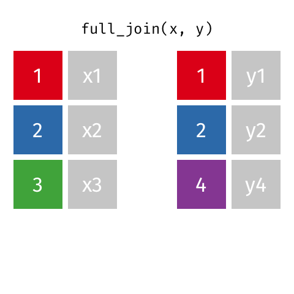

## Up next

- Slicing rows by column
- Filtering rows by logical conditions
- Defining new variables from scratch or by operations on existing variables (`mutate`)
- Aggregations (min, mean, max, etc.)

## Visualization

Plotting libraries often operate in such a way that tidy data is easier to plot.

```r
weather1 |> ggplot(aes(x=DATE, y=TMAX)) +
  geom_line()
```

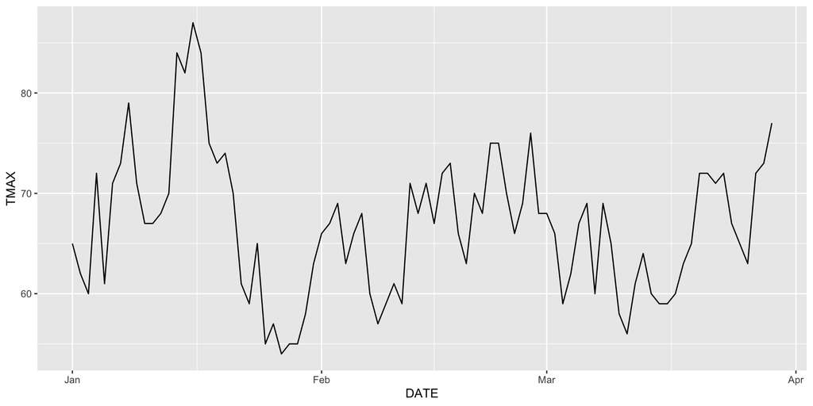

## Exceptions?

There will be situations where you’ll need to deviate from the tidy format for various purposes.

Sometimes, plotting and table construction require reshaping data into non-tidy formats, for example:

```r
weather4 <- weather1 |>
  pivot_longer(cols = c("TMIN", "TMAX"),
               values_to="Temp",
               names_to="Min/Max")

weather4 |> ggplot(aes(x=DATE, y=Temp, col=`Min/Max`)) +
  geom_line()
```

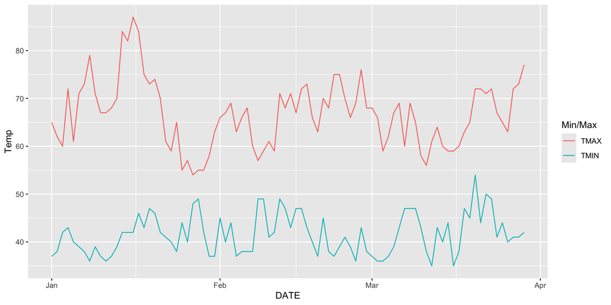

## Exceptions?

```r
mammal2 |> filter(species %in% c("Rabbit", "Raccoon", "Sheep")) |>
  ggplot() +
  geom_col(aes(y=weight, x=species, fill=measurement),
           position="dodge") +
  coord_flip()
```

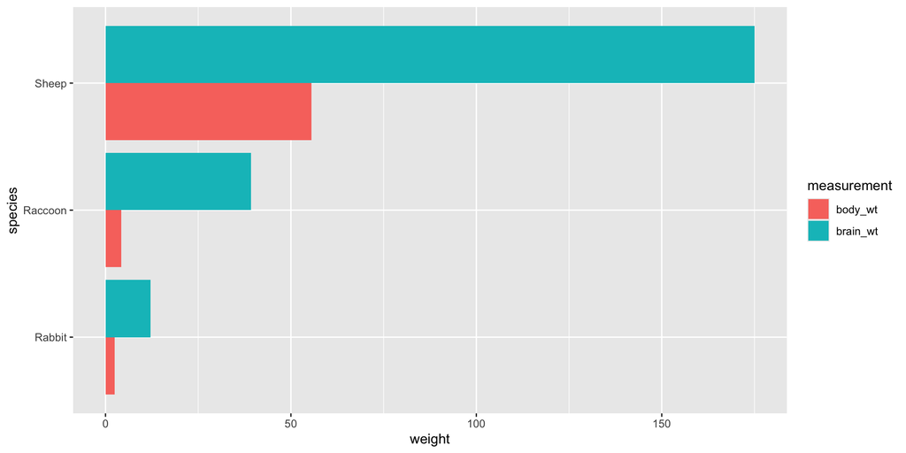

## Tidy data is not easy to look at

- Tidy data is optimized for computation and visualization
- Most data in a spreadsheet won’t be tidy!
- When presenting tables, tidy is usually not optimal

## Review: The Tidy Data Format

The tidy data format is defined by three key principles:

1. Each variable forms a column.
2. Each observation forms a row.
3. Each type of observational unit forms a table.

## The tidy format

Tidy data typically has these characteristics:

- Each cell contains a single value.
- Column headers are variable names, not values.
- Variables are stored in columns, not rows.
- Different types of variables are stored in different tables.

## Tidy Data Format

**Advantages:**

- Consistent format
- Easy visualization with `ggplot2`
- Simplifies data manipulation.
  - Tools like dplyr and tidyr work efficiently with tidy data, making data transformation more straightforward.
- Facilitates analysis
  - Many statistical and machine learning functions in R expect data in a tidy format.

## Tidy Data Format

**Disadvantages:**

- Learning curve
- Storage inefficiency
- Not always intuitive
  - For some types of data or analyses, a wide format might be more natural
  - Not good for examining by eye (e.g. in a spreadsheet)

## Review

- In tidy data, rows and columns correspond to observations and variables.
  - This provides a standard dataset structure that facilitates exploration and analysis.
  - Many datasets are not stored in this format.
- Transformation operations are a lot easier with tidy data.
  - Due in part to the way tools in pandas are designed.
  - The goal of lab 1 is to learn these operations.
- There are situations where non-tidy data is useful.
  - In PSTAT100, these will usually arise in plotting and tabulation tasks.

## Up next

- Slicing rows by column
- Filtering rows by logical conditions
- Defining new variables from scratch or by operations on existing variables (`mutate`)
- Aggregations (min, mean, max, etc.)

# Appendix

## Advanced Tidying

Let’s revisit the `billboard` dataset.

- Song rankings for Billboard top 100 in the year 2000
- Variables: `artist`, `track`, `date.enter` (data song entered the top 100) and `wk1`-`wk76`, the rank fo the song in each week after it entered.

```r
billboard |> select(1:10)
```

```
# A tibble: 317 × 10
   artist         track   date.entered   wk1   wk2   wk3   wk4   wk5   wk6   wk7
   <chr>          <chr>   <date>       <dbl> <dbl> <dbl> <dbl> <dbl> <dbl> <dbl>
 1 2 Pac          Baby D… 2000-02-26      87    82    72    77    87    94    99
 2 2Ge+her        The Ha… 2000-09-02      91    87    92    NA    NA    NA    NA
 3 3 Doors Down   Krypto… 2000-04-08      81    70    68    67    66    57    54
 4 3 Doors Down   Loser   2000-10-21      76    76    72    69    67    65    55
 5 504 Boyz       Wobble… 2000-04-15      57    34    25    17    17    31    36
 6 98^0           Give M… 2000-08-19      51    39    34    26    26    19     2
 7 A*Teens        Dancin… 2000-07-08      97    97    96    95   100    NA    NA
 8 Aaliyah        I Don'… 2000-01-29      84    62    51    41    38    35    35
 9 Aaliyah        Try Ag… 2000-03-18      59    53    38    28    21    18    16
10 Adams, Yolanda Open M… 2000-08-26      76    76    74    69    68    67    61
# ℹ 307 more rows
```

How to collect all the “weeks” into one variable?

## Tidying Data

We can use `pivot_longer()`:

```r
billboard |>
  pivot_longer(cols = starts_with("wk"),
               names_to = "week",
               values_to = "rank")
```

```
# A tibble: 24,092 × 5
   artist track                   date.entered week   rank
   <chr>  <chr>                   <date>       <chr> <dbl>
 1 2 Pac  Baby Don't Cry (Keep... 2000-02-26   wk1      87
 2 2 Pac  Baby Don't Cry (Keep... 2000-02-26   wk2      82
 3 2 Pac  Baby Don't Cry (Keep... 2000-02-26   wk3      72
 4 2 Pac  Baby Don't Cry (Keep... 2000-02-26   wk4      77
 5 2 Pac  Baby Don't Cry (Keep... 2000-02-26   wk5      87
 6 2 Pac  Baby Don't Cry (Keep... 2000-02-26   wk6      94
 7 2 Pac  Baby Don't Cry (Keep... 2000-02-26   wk7      99
 8 2 Pac  Baby Don't Cry (Keep... 2000-02-26   wk8      NA
 9 2 Pac  Baby Don't Cry (Keep... 2000-02-26   wk9      NA
10 2 Pac  Baby Don't Cry (Keep... 2000-02-26   wk10     NA
# ℹ 24,082 more rows
```

What if we don’t like the “wk” prefix.

## Extra functions of `pivot_longer()`

```r
billboard_long <- billboard |>
  pivot_longer(cols = starts_with("wk"),
               names_to = "week",
               names_prefix = "wk",  ## will remove wk for us
               values_to = "rank")
billboard_long
```

```
# A tibble: 24,092 × 5
   artist track                   date.entered week   rank
   <chr>  <chr>                   <date>       <chr> <dbl>
 1 2 Pac  Baby Don't Cry (Keep... 2000-02-26   1        87
 2 2 Pac  Baby Don't Cry (Keep... 2000-02-26   2        82
 3 2 Pac  Baby Don't Cry (Keep... 2000-02-26   3        72
 4 2 Pac  Baby Don't Cry (Keep... 2000-02-26   4        77
 5 2 Pac  Baby Don't Cry (Keep... 2000-02-26   5        87
 6 2 Pac  Baby Don't Cry (Keep... 2000-02-26   6        94
 7 2 Pac  Baby Don't Cry (Keep... 2000-02-26   7        99
 8 2 Pac  Baby Don't Cry (Keep... 2000-02-26   8        NA
 9 2 Pac  Baby Don't Cry (Keep... 2000-02-26   9        NA
10 2 Pac  Baby Don't Cry (Keep... 2000-02-26   10       NA
# ℹ 24,082 more rows
```

See any other problems with `week`?

## Extra functions of `pivot_longer()`

With one more tweak…

```r
billboard_long <- billboard |>
  pivot_longer(cols = starts_with("wk"),
               names_to = "week",
               names_prefix = "wk",
               names_transform = list(week = as.integer),
               values_to = "rank")
billboard_long
```

```
# A tibble: 24,092 × 5
   artist track                   date.entered  week  rank
   <chr>  <chr>                   <date>       <int> <dbl>
 1 2 Pac  Baby Don't Cry (Keep... 2000-02-26       1    87
 2 2 Pac  Baby Don't Cry (Keep... 2000-02-26       2    82
 3 2 Pac  Baby Don't Cry (Keep... 2000-02-26       3    72
 4 2 Pac  Baby Don't Cry (Keep... 2000-02-26       4    77
 5 2 Pac  Baby Don't Cry (Keep... 2000-02-26       5    87
 6 2 Pac  Baby Don't Cry (Keep... 2000-02-26       6    94
 7 2 Pac  Baby Don't Cry (Keep... 2000-02-26       7    99
 8 2 Pac  Baby Don't Cry (Keep... 2000-02-26       8    NA
 9 2 Pac  Baby Don't Cry (Keep... 2000-02-26       9    NA
10 2 Pac  Baby Don't Cry (Keep... 2000-02-26      10    NA
# ℹ 24,082 more rows
```

Transformations of data frames are operations that modify the **shape**, **values**, or **class of values** of a data frame. (I didn’t expect `pivot_longer()` could do all three!)